# Notes on Chapter 7

The Caveman Coder

2025-12-31

# Chapter 7: Spatio-temporal modeling of areal data.

Aim: Estimate risk of lung cancer in Ohio using the **R-INLA** pakage and visualize data using **ggplot2**, **plotly**, and **gganimate**. Data are obtained from the **SpatialEpiApp** package.

Note: **SpatialEpiApp** is no longer available in CRAN. Manually installing the package is also problematic due to deprecated dependencies.

## Data and map

Loading the data source `dataohiocomplete.csv`:

```r
dohio <- read.csv("data/dataohiocomplete.csv")
head(dohio)
```

```
##   county gender race year y     n  NAME
## 1      1      1    1 1968 6  8912 Adams
## 2      1      1    1 1969 5  9139 Adams
## 3      1      1    1 1970 8  9455 Adams
## 4      1      1    1 1971 5  9876 Adams
## 5      1      1    1 1972 8 10281 Adams
## 6      1      1    1 1973 5 10876 Adams
```

Loading the shafefile:

```r
library(sf)
```

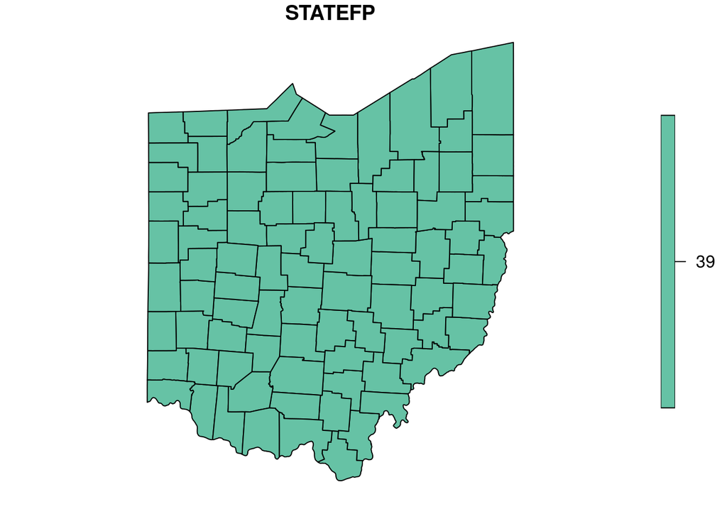

Map of Ohio counties

```r
map <- st_read("data/fe_2007_39_county/fe_2007_39_county.shp")
plot(map[1])
```

## Data preparation

The data contain the number of lung cancer cases and population stratified by gender and race in each of the Ohio counties from 1968 to 1988.

### Observed cases

Obtaining the number of cases for all the strata in each county and year:

```r
library(dplyr)
head(dohio)
```

```
##   county gender race year y     n  NAME
## 1      1      1    1 1968 6  8912 Adams
## 2      1      1    1 1969 5  9139 Adams
## 3      1      1    1 1970 8  9455 Adams
## 4      1      1    1 1971 5  9876 Adams
## 5      1      1    1 1972 8 10281 Adams
## 6      1      1    1 1973 5 10876 Adams
```

```r
d <- aggregate(
  x = dohio$y,
  by = list(county = dohio$NAME, year = dohio$year),
  FUN = sum
)

names(d) <- c("county", "year", "Y")
head(d)
```

```
##      county year  Y
## 1     Adams 1968  6
## 2     Allen 1968 32
## 3   Ashland 1968 15
## 4 Ashtabula 1968 27
## 5    Athens 1968 12
## 6  Auglaize 1968  7
```

Or in **dplyr**:

```r
dohio |>
  select(NAME, year, y) |>
  group_by(year, NAME) |>
  summarize(Y = sum(y)) |>
  rename(county = NAME)
```

```
## # A tibble: 1,848 × 3
## # Groups:   year [21]
##     year county        Y
##    <int> <chr>     <int>
##  1  1968 Adams         6
##  2  1968 Allen        32
##  3  1968 Ashland      15
##  4  1968 Ashtabula    27
##  5  1968 Athens       12
##  6  1968 Auglaize      7
##  7  1968 Belmont      25
##  8  1968 Brown        10
##  9  1968 Butler       49
## 10  1968 Carroll       3
## # ℹ 1,838 more rows
```

### Expected cases

To calculate the expected number of cases using indirected standardization with the `expected()` function of the **SpatialEpi** package. But before doing that, we need to sort the values of the data `dohio` which is required by the `expected()` function.

Sorting the values of `dohio`:

```r
dohio <- dohio[order(
  dohio$county,
  dohio$year,
  dohio$gender,
  dohio$race
), ]
```

Inspecting the first rows ot the sorted data:

```r
dohio[1:20, ]
```

```
##    county gender race year y     n  NAME
## 1       1      1    1 1968 6  8912 Adams
## 22      1      1    2 1968 0    24 Adams
## 43      1      2    1 1968 0  8994 Adams
## 64      1      2    2 1968 0    22 Adams
## 2       1      1    1 1969 5  9139 Adams
## 23      1      1    2 1969 0    20 Adams
## 44      1      2    1 1969 0  9289 Adams
## 65      1      2    2 1969 0    24 Adams
## 3       1      1    1 1970 8  9455 Adams
## 24      1      1    2 1970 0    18 Adams
## 45      1      2    1 1970 1  9550 Adams
## 66      1      2    2 1970 0    24 Adams
## 4       1      1    1 1971 5  9876 Adams
## 25      1      1    2 1971 0    20 Adams
## 46      1      2    1 1971 1  9991 Adams
## 67      1      2    2 1971 0    27 Adams
## 5       1      1    1 1972 8 10281 Adams
## 26      1      1    2 1972 0    23 Adams
## 47      1      2    1 1972 2 10379 Adams
## 68      1      2    2 1972 0    31 Adams
```

Calculating the expected number of cases using the `expected()` function:

```r
library(SpatialEpi)
n.strata <- 4
E <- expected(
  population = dohio$n,
  cases = dohio$y,
  n.strata = n.strata
)
```

Now we need to create a new dataframe with the expected counts for each county and year. We will call this `dE`. To do this, we need to detemine the number of years and create a vector of counties where each county repeats `nyears` times:

```r
nyears <- length(unique(dohio$year))
countiesE <- rep(unique(dohio$NAME), each = nyears)
```

The corresponding years of `E` are obtained by repeating the whole vector of years `ncounties` times:

```r
ncounties <- length(unique(dohio$NAME))
yearsE <- rep(unique(dohio$year), times = ncounties)
```

Finally, the new dataframe `dE` can be created:

```r
dE <- data.frame(county = countiesE, year = yearsE, E = E)

head(dE)
```

```
##   county year         E
## 1  Adams 1968  8.278660
## 2  Adams 1969  8.501767
## 3  Adams 1970  8.779313
## 4  Adams 1971  9.175276
## 5  Adams 1972  9.548736
## 6  Adams 1973 10.099777
```

We need to merge this with `d`.

Merging `dE` with `d`:

```r
d <- merge(d, dE, by = c("county", "year"))
head(d)
```

```
##   county year  Y         E
## 1  Adams 1968  6  8.278660
## 2  Adams 1969  5  8.501767
## 3  Adams 1970  9  8.779313
## 4  Adams 1971  6  9.175276
## 5  Adams 1972 10  9.548736
## 6  Adams 1973  7 10.099777
```

### SIRs

Calculating the SIR or county $i$ and year $j$:

```r
d$SIR <- d$Y / d$E
head(d)
```

```
##   county year  Y         E       SIR
## 1  Adams 1968  6  8.278660 0.7247549
## 2  Adams 1969  5  8.501767 0.5881130
## 3  Adams 1970  9  8.779313 1.0251372
## 4  Adams 1971  6  9.175276 0.6539313
## 5  Adams 1972 10  9.548736 1.0472591
## 6  Adams 1973  7 10.099777 0.6930846
```

### Adding data to map

We need to add the data `d` to the `map` object. However, data `d` is in long format. Solution: transform data `d` from long format to wide format, then add to `map`.

Transforming data `d` from long to wide format using the `reshape()` function:

```r
dw <- reshape(
  d,
  timevar = "year",
  idvar = "county",
  direction = "wide"
)

dw[1:2, ]
```

```
##    county Y.1968   E.1968  SIR.1968 Y.1969    E.1969  SIR.1969 Y.1970    E.1970
## 1   Adams      6  8.27866 0.7247549      5  8.501767 0.5881130      9  8.779313
## 22  Allen     32 51.03748 0.6269902     33 50.955529 0.6476235     39 50.900771
##     SIR.1970 Y.1971    E.1971  SIR.1971 Y.1972    E.1972  SIR.1972 Y.1973
## 1  1.0251372      6  9.175276 0.6539313     10  9.548736 1.0472591      7
## 22 0.7661967     44 51.216808 0.8590930     36 50.802554 0.7086258     38
##      E.1973  SIR.1973 Y.1974   E.1974  SIR.1974 Y.1975   E.1975  SIR.1975
## 1  10.09978 0.6930846     12 10.40512 1.1532783     12 10.25553 1.1701005
## 22 50.65118 0.7502294     41 50.79817 0.8071157     35 50.82988 0.6885714
##    Y.1976   E.1976  SIR.1976 Y.1977   E.1977 SIR.1977 Y.1978   E.1978  SIR.1978
## 1      10 10.68397 0.9359817      7 10.86150 0.644478     13 11.01995 1.1796782
## 22     54 50.31044 1.0733358     63 50.63584 1.244178     42 50.33976 0.8343305
##    Y.1979   E.1979  SIR.1979 Y.1980   E.1980  SIR.1980 Y.1981   E.1981 SIR.1981
## 1       5 11.02760 0.4534077     14 11.19071 1.2510377     12 11.33656 1.058522
## 22     76 51.03841 1.4890747     46 51.23283 0.8978618     53 51.19716 1.035214
##    Y.1982   E.1982  SIR.1982 Y.1983   E.1983  SIR.1983 Y.1984   E.1984 SIR.1984
## 1      15 11.31605 1.3255506      9 11.19844 0.8036835     12 11.15124 1.076114
## 22     47 50.34020 0.9336474     62 49.93707 1.2415626     69 50.38507 1.369453
##    Y.1985   E.1985 SIR.1985 Y.1986   E.1986 SIR.1986 Y.1987   E.1987 SIR.1987
## 1      20 11.20256 1.785306     12 11.35723 1.056595     16 11.58485 1.381114
## 22     53 50.56189 1.048220     65 50.78884 1.279809     69 51.13667 1.349325
##    Y.1988   E.1988 SIR.1988
## 1      15 11.71545 1.280361
## 22     58 51.34226 1.129674
```

Viewing the original map first:

```r
map[1:2, ]
```

```
## Simple feature collection with 2 features and 11 fields
## Geometry type: POLYGON
## Dimension:     XY
## Bounding box:  xmin: -84.45623 ymin: 40.35453 xmax: -82.72418 ymax: 40.99694
## Geodetic CRS:  NAD83
##   STATEFP COUNTYFP COUNTYNS CNTYIDFP     NAME        NAMELSAD LSAD CLASSFP
## 1      39      011     <NA>    39011 Auglaize Auglaize County   06      H1
## 2      39      033     <NA>    39033 Crawford Crawford County   06      H1
##   MTFCC UR FUNCSTAT                       geometry
## 1 G4020  M        A POLYGON ((-84.13476 40.6575...
## 2 G4020  M        A POLYGON ((-82.77258 40.9958...
```

Merging the `map` and `dw` using `left_join()`:

```r
map <- dplyr::left_join(map, dw, by = c("NAME" = "county"))

map[1:2, ]
```

```
## Simple feature collection with 2 features and 74 fields
## Geometry type: POLYGON
## Dimension:     XY
## Bounding box:  xmin: -84.45623 ymin: 40.35453 xmax: -82.72418 ymax: 40.99694
## Geodetic CRS:  NAD83
##   STATEFP COUNTYFP COUNTYNS CNTYIDFP     NAME        NAMELSAD LSAD CLASSFP
## 1      39      011     <NA>    39011 Auglaize Auglaize County   06      H1
## 2      39      033     <NA>    39033 Crawford Crawford County   06      H1
##   MTFCC UR FUNCSTAT Y.1968   E.1968  SIR.1968 Y.1969   E.1969  SIR.1969 Y.1970
## 1 G4020  M        A      7 17.26366 0.4054761     10 17.39818 0.5747729      8
## 2 G4020  M        A     14 22.12711 0.6327080     19 22.59063 0.8410565     27
##     E.1970  SIR.1970 Y.1971   E.1971  SIR.1971 Y.1972  E.1972  SIR.1972 Y.1973
## 1 17.56751 0.4553862     16 17.89071 0.8943190      6 18.0501 0.3324082     15
## 2 22.98028 1.1749205     13 23.57830 0.5513545     18 23.4586 0.7673092     18
##     E.1973  SIR.1973 Y.1974   E.1974  SIR.1974 Y.1975   E.1975  SIR.1975 Y.1976
## 1 18.45380 0.8128406     12 18.70279 0.6416156     12 19.42100 0.6178877     20
## 2 23.63826 0.7614772     13 23.45568 0.5542367     24 23.31043 1.0295820     25
##     E.1976 SIR.1976 Y.1977   E.1977  SIR.1977 Y.1978   E.1978  SIR.1978 Y.1979
## 1 18.89495 1.058484     18 18.98767 0.9479838     11 19.23123 0.5719864     18
## 2 23.30527 1.072719     17 23.16233 0.7339505     30 23.40204 1.2819398     23
##     E.1979  SIR.1979 Y.1980   E.1980  SIR.1980 Y.1981   E.1981  SIR.1981 Y.1982
## 1 19.43616 0.9261090     17 19.44231 0.8743815     20 19.55111 1.0229598     23
## 2 23.09628 0.9958315     28 22.68541 1.2342735     21 22.70391 0.9249507     37
##     E.1982 SIR.1982 Y.1983   E.1983  SIR.1983 Y.1984   E.1984 SIR.1984 Y.1985
## 1 19.60303 1.173288     16 19.50550 0.8202817     35 19.78027 1.769440     22
## 2 22.46795 1.646790     21 22.10987 0.9498020     26 22.39066 1.161198     35
##     E.1985 SIR.1985 Y.1986   E.1986 SIR.1986 Y.1987   E.1987  SIR.1987 Y.1988
## 1 19.87985 1.106648     23 19.93749 1.153606     19 20.08397 0.9460279     22
## 2 22.37403 1.564314     30 22.16364 1.353568     24 22.17823 1.0821420     31
##     E.1988 SIR.1988                       geometry
## 1 20.19728 1.089255 POLYGON ((-84.13476 40.6575...
## 2 22.13053 1.400780 POLYGON ((-82.77258 40.9958...
```

## Mapping SIRs

To plot `map` object, we need to transform the data from wide to long format. The **tidyr** function `gather()` is useful here:

```r
library(tidyr)
map <- gather(map, year, SIR, paste0("SIR.", 1968:1988))
```

Converting the values generated by the `paste0` function above to integers (aka years):

```r
map$year <- as.integer(substring(map$year, 5, 8))
```

Plotting with faceting:

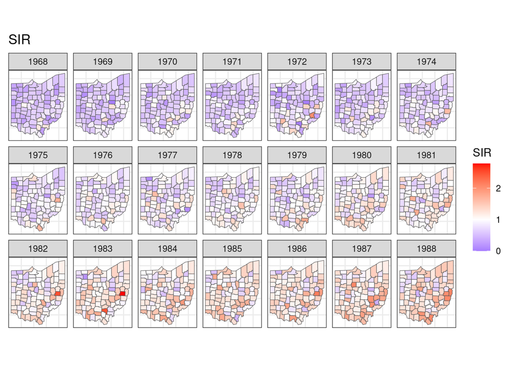

Maps of lung cancer SIR in Ohio counties from 1968 to 1988 created with a diverging color scale.

```r
library(ggplot2)

map |> ggplot() +
  geom_sf(aes(fill = SIR)) +
  facet_wrap(~year, dir = "h", ncol = 7) +
  ggtitle("SIR") +
  theme_bw() +
  theme(
    axis.text.x = element_blank(),
    axis.text.y = element_blank(),
    axis.ticks = element_blank()
  ) +
  scale_fill_gradient2(
    midpoint = 1,
    low = "blue",
    mid = "white",
    high = "red"
  )
```

## Time plots of SIRs

Plotting the SIRs of each of the counties over time:

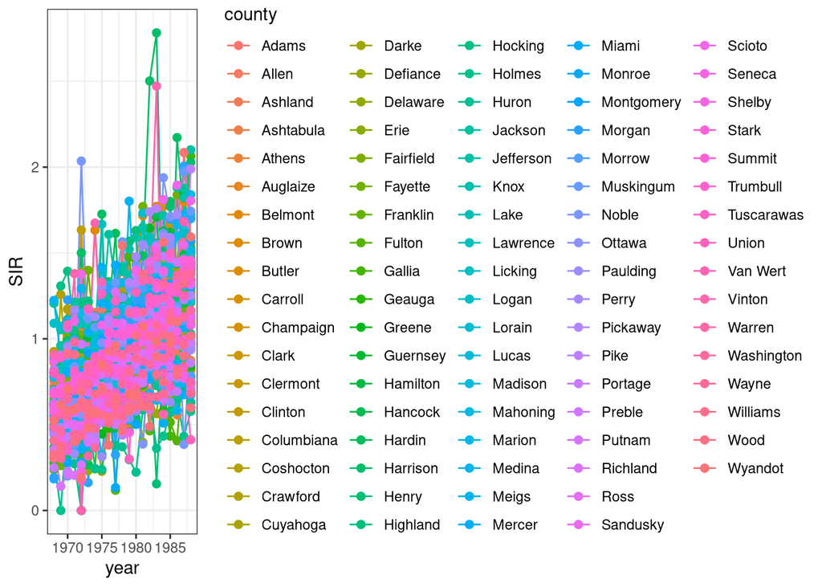

Time plot of lung cancer SIR in Ohio counties from 1968 to 1988.

```r
g <- ggplot(
  d, aes(x = year, y = SIR, group = county, color = county)
 ) +
  geom_line() +
  geom_point(size = 2) +
  theme_bw()

g
```

Removing the legend from plot:

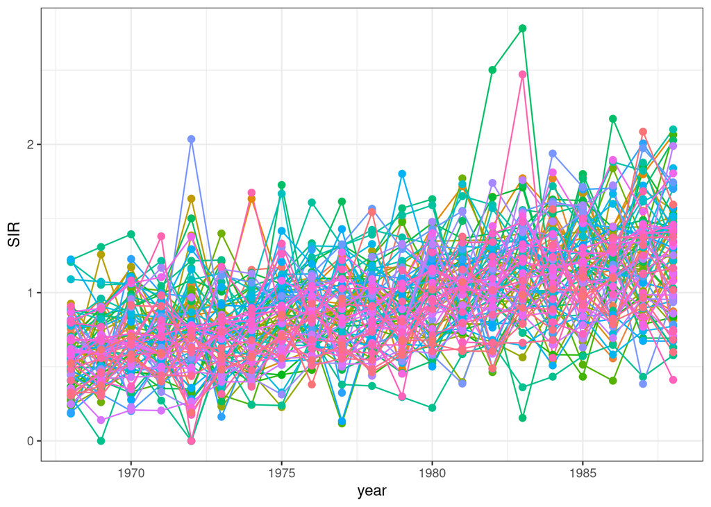

```r
g <- g + theme(legend.position = "none")
g
```

Highlighting the time series plot of a specific county (say, Adams) using the `gghighlight()` function from the **gghighlight** package:

```r
library(gghighlight)

g + gghighlight(county == "Adams")
```

```
## label_key: county
```

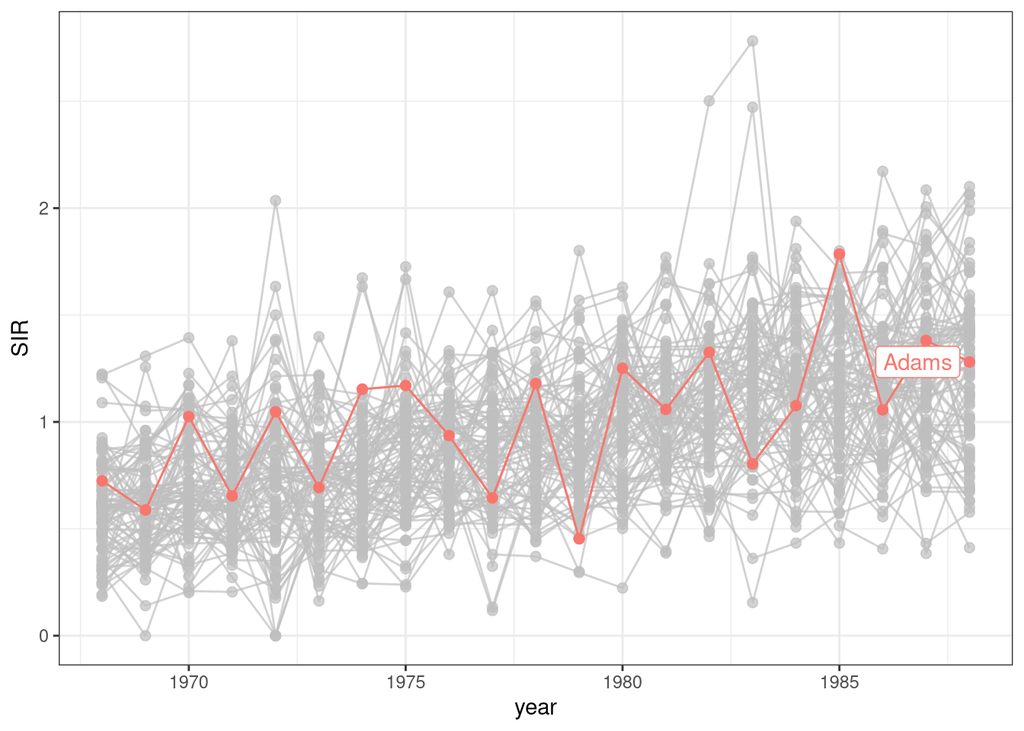

Transforming the plot to an interactive one using the **plotly** package:

```r
library(plotly)
ggplotly(g)
```

[interactive chart not shown]

## Modeling

Spatio-temporal modeling using **R-INLA** to obtain disease risk estimates.

### Model

The Bernardinelli model will be used to estimate the relative risk of lung cancer for each Ohio county and year. This model ass;umes that the number of cases $Y_{ij}$ observed in county $i$ and year $j$ are modeled as:
$$Y_{ij} \sim Po(E_{ij}\theta_{ij}),$$
where $Y_{ij}$ us the observed number of cases, $E_{ij}$ is the expected number of cases, and $\theta_{ij}$ is the relative risk of county $i$ and year $j$…

### Neighborhood matrix

Creating a neighborhood matrix (necessary to define the spatial random effect) using `poly2nb()` and `nb2INLA()` functions from the **spdep** package:

```r
library(INLA)
library(spdep)
```

```r
nb <- poly2nb(map)
head(nb)
```

```
## [[1]]
##   [1]   26   55   71   72   80   85   89  114  143  159  160  168  173  177  202
##  [16]  231  247  248  256  261  265  290  319  335  336  344  349  353  378  407
##  [31]  423  424  432  437  441  466  495  511  512  520  525  529  554  583  599
##  [46]  600  608  613  617  642  671  687  688  696  701  705  730  759  775  776
##  [61]  784  789  793  818  847  863  864  872  877  881  906  935  951  952  960
##  [76]  965  969  994 1023 1039 1040 1048 1053 1057 1082 1111 1127 1128 1136 1141
##  [91] 1145 1170 1199 1215 1216 1224 1229 1233 1258 1287 1303 1304 1312 1317 1321
## [106] 1346 1375 1391 1392 1400 1405 1409 1434 1463 1479 1480 1488 1493 1497 1522
## [121] 1551 1567 1568 1576 1581 1585 1610 1639 1655 1656 1664 1669 1673 1698 1727
## [136] 1743 1744 1752 1757 1761 1786 1815 1831 1832 1840 1845
##
## [[2]]
##   [1]   19   35   42   70   82   86   90  107  123  130  158  170  174  178  195
##  [16]  211  218  246  258  262  266  283  299  306  334  346  350  354  371  387
```

[output cut: 54 more lines]

Converting the matrix into the format required by INLA:

```r
nb2INLA("map.adj", nb)
```

Reading the newly-created graph using `inla.read.graph()`:

```r
g <- inla.read.graph(filename = "map.adj")
```

### Inference using INLA

Creating the index vectors for the counties and years that will be used to specify the random effects of the model:

```r
d$idarea <- as.numeric(as.factor(d$county))
d$idarea1 <- d$idarea
d$idtime <- 1 + d$year - min(d$year)
```

Note that the vector `idarea` was replicated. Reason: we need to use the index vector of the areas in two different random effects, and **R-INLA** variables can only be associated with an `f()` function only once.

Formula for the Bernardinalli model:
$$Y_{ij} \sim Po(E_{ij}\theta_{ij}) \\
\log(\theta_{ij}) = \alpha + u_i + v_i + (\beta + \delta_i) \times t_j$$
Writing the formula in R-code:

```r
formula <- Y ~ f(idarea, model = "bym", graph = g) +
  f(idarea1, idtime, model = "iid") + idtime
```

The first `f()` corresponds to $u_i + v_i$ and the second `f()` is the $\delta_i \times t_j$ part.

Calling the `inla()` function to run the model and generate results:

```r
res <- inla(
  formula,
  family = "poisson",
  data = d,
  E = E,
  control.predictor = list(compute = TRUE)
)
```

Again, the `control.predictor` argument is set to `list(compute = TRUE)` to include the posterior means of the predictors in the results.

## Mapping relative risks

Extracting the relative risk estimates and lower and upper limits of the 95% credible intervals and adding them to `d` to make mapping easier and the code more readable:

```r
d$RR <- res$summary.fitted.values[, "mean"]
d$LL <- res$summary.fitted.values[, "0.025quant"]
d$UL <- res$summary.fitted.values[, "0.975quant"]
```

Merging `d` with `map` to include the columns `RR`, `LL`, and `UL` in the plot:

```r
map <- merge(
  map, d,
  by.x = c("NAME", "year"),
  by.y = c("county", "year")
)
```

Using `ggplot` to create the plot:

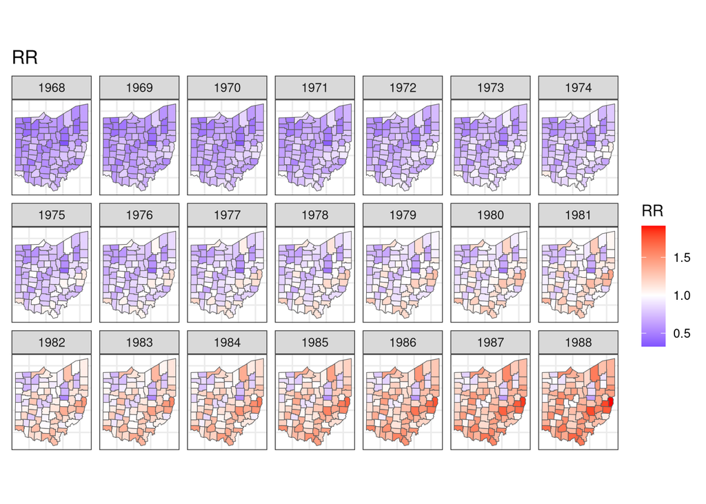

Maps of lung cancer relative risk in Ohio conties from 1968 to 1988.

```r
map |> ggplot() +
  geom_sf(aes(fill = RR)) +
  facet_wrap(~ year, dir = "h", ncol = 7) +
  ggtitle("RR") +
  theme_bw() +
  theme(
    axis.text.x = element_blank(),
    axis.text.y = element_blank(),
    axis.ticks = element_blank()
  ) +
  scale_fill_gradient2(
    midpoint = 1,
    low = "blue",
    mid = "white",
    high = "red"
  )
```

Using **gganimate** to create an animated version of this map, instead of faceting by year:

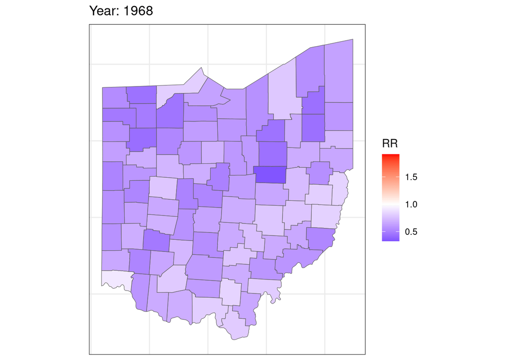

Animation of lung cancer relative risk in Ohio counties from 1968 to 1988.

```r
library(gganimate)

p <- map |> ggplot() +
  geom_sf(aes(fill = RR)) +
  theme_bw() +
  theme(
    axis.text.x = element_blank(),
    axis.text.y = element_blank(),
    axis.ticks = element_blank()
  ) + scale_fill_gradient2(
    midpoint = 1,
    low = "blue",
    mid = "white",
    high = "red"
  ) +
  transition_time(year) +
  labs(title = "Year: {round(frame_time, 0)}")

p
```

Saving the animation:

```r
anim_save(
  "OhioLungCancerRR.gif",
  animation = p,
  width = 800,
  height = 600,
  res = 100,
  fps = 20
)
```